# Analysis on the Police Violence in the United States between Jan 2013 and Nov 2021

Camila Garcia

12/10/2021

# PROJECT BACKGROUND

As of November 2021, 910 people have been killed by the Police in the US. The deaths of George Floyd, Breonna Taylor and Michael Brown have attracted significant attention in the media due to excessive use of force by the police, particularly on racial minotiries. Multiple factors can influence police response when encountering situations related to domestic disturbance, violent crimes, non violence offenses, traffic stops etc. One of this determining factors could be whether the police officer believes that the individual is carrying a weapon or not. I was particularly interested to see if from the fatal encounters, we could use the variables in the data set to predict whether an individual is armed or not. This information could be particularly important to develop future training for police officers and prevent some of these killings. This report includes Statistical and graphical data analysis to enhanced understanding of the content and help identify any particular trends relevant to develop our model.

This report analysis police killings, referring to those encounters with the police that resulted in an individual being shot, beaten, restrained, intentionally hit by a police vehicle, pepper sprayed, tasered, or otherwise harmed by police officers, whether on-duty or off-duty.

The data to perform this analysis was extracted from Mapping Police Violence Inc., a non-profit organization and independent research collaborative collecting comprehensive data on police killings nationwide to quantify the impact of police violence in the US. Data used for this investigation can be found at: https://mappingpoliceviolence.org/aboutthedata

The dataset analyzed includes 9,677 encounters that occurred between January 1st 2013 and November 3rd 2021. It containing 53 variables including relevant information about the victim (age, race, gender), location where the incident occurred (city, state, latitude and longitude coordinates, geography), how the encountered occured and how did the officer responded (cause of death of the victim, body camera used, type of encounter, initial encounter reason, etc.), political information (congressional district, representative party), among other variables.

Please note the data file used to perform this analysis was downloaded on November 18th of 2021. Given the organization updates this data file every weekend information and trends could vary overtime.

#Hypothesis and assumptions prior to analysis

Before starting our analysis my hypothesis and assumptions are the following: - Police Brutality will be the highest among racial minorities - Largest number of killings will be found in urban areas/ most dense areas - Police officers used a body camera 50% of the time - Political affiliation of Victim’s representative impacts whether the individual was alledged to use an arm - There is no correlation between race and armed/unarmed - gender is significant to determine if an individual was allergly armed/unarmed - Police violence has increased over the past few years - Variables in our dataset should provide a prediciton of the armed/unarmed dataset with an accuracy score above 80%.

# IMPORTING FILE AND DATA CLEANING

This dataset includes variables formated in characters, numbers and int. Based on the dataset structure, it can be observed that the majority of the variables are categorical. Extensive data cleaning was performed in order to analyze the data. This data cleaning consisted in removing null values, performing consistent formatting across multiple variables, changing the name of the columns, creating new ones and converting the data into numerical values.

```r
library(MASS)
library(plyr)
library(dplyr)
library(ggplot2)
library(knitr)
#library(rnaturalearth)
#library(rworldmap)
#library(sf)
library(tidyverse)


mpv <- read.csv("~/Carnegie_Mellon/Courses/94842 - Programming R for Analytics/Project/MPV.csv")
str(mpv)
```

```
## 'data.frame':    9677 obs. of  53 variables:
##  $ Victim.s.name                                                                                                                                                             : chr  "Jose Enrique Cortez" "Johnny Michael Gilbert" "Name withheld by police" "Name withheld by police" ...
##  $ Victim.s.age                                                                                                                                                              : chr  "26" "43" "30" "Unknown" ...
##  $ Victim.s.gender                                                                                                                                                           : chr  "Male" "Male" "Male" "Male" ...
##  $ Victim.s.race                                                                                                                                                             : chr  "Hispanic" "Unknown race" "Unknown race" "Unknown race" ...
##  $ URL.of.image.of.victim                                                                                                                                                    : chr  "" "" "" "" ...
##  $ Date.of.Incident..month.day.year.                                                                                                                                         : chr  "11/3/2021" "11/3/2021" "11/3/2021" "11/3/2021" ...
##  $ Street.Address.of.Incident                                                                                                                                                : chr  "Ocotillo Road" "Spillers Road" "" "Chipman Ridge Road" ...
##  $ City                                                                                                                                                                      : chr  "Glendale" "Covington " "Eau Claire" "Williamstown" ...
##  $ State                                                                                                                                                                     : chr  "AZ" "GA" "WI" "KY" ...
##  $ Zipcode                                                                                                                                                                   : int  NA 30014 NA NA NA NA 91401 17112 37312 NA ...
##  $ County                                                                                                                                                                    : chr  "Maricopa" "Newton" "Eau Claire" "Grant" ...
##  $ Agency.responsible.for.death                                                                                                                                              : chr  "Glendale Police Department" "Covington Police Department" "Eau Claire Police Department" "Kentucky State Police" ...
##  $ ORI.Agency.Identifier..if.available.                                                                                                                                      : chr  "AZ0071300" "GA1070100" "WI0180100" "KYKSP0000" ...
##  $ Cause.of.death                                                                                                                                                            : chr  "Gunshot" "Gunshot" "Gunshot" "Gunshot" ...
```

[output cut: 39 more lines]

## Counting the number of nulls in the dataset

```r
#Quantifying the number of NULLS
na_count <- lapply(mpv,function(x) { length(which(is.na(x)))})
na_count
```

```
## $Victim.s.name
## [1] 0
##
## $Victim.s.age
## [1] 0
##
## $Victim.s.gender
## [1] 0
##
## $Victim.s.race
## [1] 0
##
## $URL.of.image.of.victim
## [1] 0
##
## $Date.of.Incident..month.day.year.
## [1] 0
##
## $Street.Address.of.Incident
## [1] 0
##
## $City
## [1] 0
##
## $State
## [1] 0
##
## $Zipcode
## [1] 68
##
## $County
## [1] 0
##
## $Agency.responsible.for.death
## [1] 0
##
## $ORI.Agency.Identifier..if.available.
## [1] 0
##
## $Cause.of.death
```

[output cut: 103 more lines]

```
##
## $Hispanic.Percent.of.the.Population.ACS
## [1] 0
##
## $Congressional.District
## [1] 0
##
## $Current.Representative.Last.name
## [1] 0
##
## $Current.Representative.First.name
## [1] 0
##
## $Current.Representative.Party
## [1] 0
```

```r
# Source: https://www.edureka.co/community/50920/code-snippet-find-number-null-values-each-column-dataframe
```

##Removing Nulls

```r
#dropping NAs from dataframe
mpv_clean <- na.omit(mpv)
head(mpv_clean)
```

```
##          Victim.s.name Victim.s.age Victim.s.gender Victim.s.race
## 119 Cody Levi Harrison           33            Male         White
## 120 Christopher George           25            Male         White
## 122  Charles Sharp III           49            Male         White
## 126     James Anderson           48            Male  Unknown race
## 129      Desmond Lewis           30            Male         Black
## 131      Joseph Manard           31            Male         White
##                                                                                                                          URL.of.image.of.victim
## 119                                                               https://fatalencounters.org/wp-content/uploads/2021/10/Cody-Levi-Harrison.png
## 120
## 122 https://www.rlsmedia.com/sites/default/files/styles/large/public/field/image/article/photoCollageMaker_20210922_111503106.jpg?itok=CnpbYKue
## 126
## 129                                                                 https://fatalencounters.org/wp-content/uploads/2021/10/Desmond-D.-Lewis.jpg
## 131                                                                     https://fatalencounters.org/wp-content/uploads/2021/10/JosephMenard.jpg
##     Date.of.Incident..month.day.year. Street.Address.of.Incident
```

[output cut: 202 more lines]

```r
print("Number of rows in dataset:")
```

```
## [1] "Number of rows in dataset:"
```

```r
nrow(mpv_clean)
```

```
## [1] 4653
```

As observed above, a significant number of nulls were removed from the data set. Our original data of 9,677 encounters was reduced to 4,653.

## Updating column names

As it can be observed below, the column names of the variables in our dataset are too long. This not only makes the code look messy but increases significantly the changes of errors when typing variables. For convenience and to improve readability, some of the column names were updated to shorter versions.

```r
print("Number of Columns: ")
```

```
## [1] "Number of Columns: "
```

```r
ncol(mpv_clean)
```

```
## [1] 53
```

```r
columns <- colnames(mpv_clean)

col_list <- paste(dQuote(colnames(mpv_clean)), collapse = ", ")
#Source: https://stackoverflow.com/questions/60987016/convert-column-names-as-a-list-in-r
col_list
```

```
## [1] "\"Victim.s.name\", \"Victim.s.age\", \"Victim.s.gender\", \"Victim.s.race\", \"URL.of.image.of.victim\", \"Date.of.Incident..month.day.year.\", \"Street.Address.of.Incident\", \"City\", \"State\", \"Zipcode\", \"County\", \"Agency.responsible.for.death\", \"ORI.Agency.Identifier..if.availabl…
```

```r
col_updated <- c("Victims.name", "Victims.age", "Victims.gender", "Victims.race", "image.of.victim", "Date.of.Incident", "Street.Address", "City", "State", "Zipcode", "County", "Agency.resp", "ORI.Agency.ID", "Cause.of.death", "description.circumstances", "Official.disposition", "Criminal.Charges", "Link", "mental.illness", "Armed.Unarmed", "Alleged.Weapon", "Alleged.Threat", "Fleeing", "Body.Camera", "WaPo.ID", "Off.Duty.Killing", "Geography", "MPV.ID", "Fatal.Encounters.ID", "Encounter.Type", "Initial.Reason", "Names.of.Officers", "Race.of.Officers", "Past.Shootings.Officer", "Call.for.Service", "Census.Tract.Code", "HUD.UPSAI.Geography", "Urban.Rural", "Median.Income", "Latitude", "Longitude", "Total.Population", "White.Non.Hisp.Pct", "Black.Non.Hisp.Pct", "Native.Amer.Pct", "Asian.Pct", "Pacific.Isl.Pct", "Other.Race.Pct", "Hisp.Pct", "Congressional.District", "Rep.Lname", "Rep.Fname", "Rep.Party")

colnames(mpv_clean) <- col_updated

colnames(mpv_clean)
```

```
##  [1] "Victims.name"              "Victims.age"
##  [3] "Victims.gender"            "Victims.race"
##  [5] "image.of.victim"           "Date.of.Incident"
##  [7] "Street.Address"            "City"
##  [9] "State"                     "Zipcode"
## [11] "County"                    "Agency.resp"
## [13] "ORI.Agency.ID"             "Cause.of.death"
## [15] "description.circumstances" "Official.disposition"
## [17] "Criminal.Charges"          "Link"
## [19] "mental.illness"            "Armed.Unarmed"
## [21] "Alleged.Weapon"            "Alleged.Threat"
## [23] "Fleeing"                   "Body.Camera"
## [25] "WaPo.ID"                   "Off.Duty.Killing"
## [27] "Geography"                 "MPV.ID"
## [29] "Fatal.Encounters.ID"       "Encounter.Type"
## [31] "Initial.Reason"            "Names.of.Officers"
## [33] "Race.of.Officers"          "Past.Shootings.Officer"
## [35] "Call.for.Service"          "Census.Tract.Code"
## [37] "HUD.UPSAI.Geography"       "Urban.Rural"
## [39] "Median.Income"             "Latitude"
## [41] "Longitude"                 "Total.Population"
## [43] "White.Non.Hisp.Pct"        "Black.Non.Hisp.Pct"
## [45] "Native.Amer.Pct"           "Asian.Pct"
## [47] "Pacific.Isl.Pct"           "Other.Race.Pct"
## [49] "Hisp.Pct"                  "Congressional.District"
## [51] "Rep.Lname"                 "Rep.Fname"
## [53] "Rep.Party"
```

## Standarization of variables

As explained above, the format of the data points in the raw data was very inconsistent. This inconsistency was making difficult the analysis of the data. Steps below were taken to standarize such variables. This process included the removal of some nulls that were coded as characters values (Unknown instead of NA), transforming variables from characters to numeric, and creating a new column for year.

Some external resources were used to find code for the transformation of characters to date, trimming variables that were causing issues in the standarization process, and the transformation from characters to percentages.

```r
#Removing values as "Unknown"
mpv_clean$Victims.age[mpv_clean$Victims.age == "Unknown"] <- NA
sum(is.na(mpv_clean$Victims.age))
```

```
## [1] 146
```

```r
mpv_clean$Victims.age = as.numeric(mpv_clean$Victims.age)

#"Standarizing variables"
mpv_clean$Body.Camera[mpv_clean$Body.Camera == "yes"] <- "Yes"
mpv_clean$Body.Camera[mpv_clean$Body.Camera == "no"] <- "No"
mpv_clean$Body.Camera[mpv_clean$Body.Camera == "Bystander Video"] <- "Other"
mpv_clean$Body.Camera[mpv_clean$Body.Camera == "surveillance video"] <- "Other"
mpv_clean$Body.Camera[mpv_clean$Body.Camera == "Surveillance video"] <- "Other"
mpv_clean$Body.Camera[mpv_clean$Body.Camera == "Surveillance Video"] <- "Other"

mpv_clean$mental.illness[mpv_clean$mental.illness == "Unknown"] <- "Unclear"
mpv_clean$mental.illness[mpv_clean$mental.illness == "unknown"] <- "Unclear"
mpv_clean$mental.illness[mpv_clean$mental.illness == "Drug or alcohol use"] <- "Drug or Alcohol Use"

mpv_clean$Armed.Unarmed <- str_trim(mpv_clean$Armed.Unarmed, side= c("both", "left", "right"))
# Source: https://stringr.tidyverse.org/reference/str_trim.html
mpv_clean$Armed.Unarmed[mpv_clean$Armed.Unarmed == "Allegedly armed"] <- "Allegedly Armed"

mpv_clean$Fleeing <- str_trim(mpv_clean$Fleeing, side= c("both", "left", "right"))
mpv_clean$Fleeing[mpv_clean$Fleeing == "car"] <- "Car"
mpv_clean$Fleeing[mpv_clean$Fleeing == "foot"] <- "Foot"
mpv_clean$Fleeing[mpv_clean$Fleeing == "not fleeing"] <- "Not Fleeing"
mpv_clean$Fleeing[mpv_clean$Fleeing == "Not fleeing"] <- "Not Fleeing"
mpv_clean$Fleeing[mpv_clean$Fleeing == "other"] <- "Other"

#Transforming string percentages to number
mpv_clean$White.Non.Hisp.Pct = as.numeric(gsub("[\\%,]", "", mpv_clean$White.Non.Hisp.Pct))*.01
mpv_clean$Asian.Pct = as.numeric(gsub("[\\%,]", "", mpv_clean$Asian.Pct))*.01
mpv_clean$Hisp.Pct = as.numeric(gsub("[\\%,]", "", mpv_clean$Hisp.Pct))*.01
mpv_clean$Black.Non.Hisp.Pct = as.numeric(gsub("[\\%,]", "", mpv_clean$Black.Non.Hisp.Pct))*.01
mpv_clean$Native.Amer.Pct = as.numeric(gsub("[\\%,]", "", mpv_clean$Native.Amer.Pct))*.01
mpv_clean$Pacific.Isl.Pct = as.numeric(gsub("[\\%,]", "", mpv_clean$Pacific.Isl.Pct))*.01
mpv_clean$Other.Race.Pct = as.numeric(gsub("[\\%,]", "", mpv_clean$Other.Race.Pct))*.01
#Source: https://datascience.stackexchange.com/questions/41605/removing-percentage-signs-with-r

mpv_clean$Date.of.Incident <- as.Date(mpv_clean$Date.of.Incident, format = "%m/%d/%Y")
mpv_clean$year <- as.numeric(format(mpv_clean$Date.of.Incident,"%Y"))
# Source: https://www.rdocumentation.org/packages/base/versions/3.6.2/topics/as.Date

mpv_clean <- na.omit(mpv_clean)

print("Total Number of Rows: ")
```

```
## [1] "Total Number of Rows: "
```

```r
nrow(mpv_clean)
```

```
## [1] 4506
```

## Transformation of data from categorical to numeric

Some of the categorical variables in our dataset were transformed into numerical variables by assigning numbers to each category from 0 to 6 depending on the variable. Please note not all the categorical variables were transformed given the significant variation of categories.

```r
mpv_num <- mpv_clean
str(mpv_num)
```

```
## 'data.frame':    4506 obs. of  54 variables:
##  $ Victims.name             : chr  "Cody Levi Harrison" "Christopher George" "Charles Sharp III" "James Anderson" ...
##  $ Victims.age              : num  33 25 49 48 30 31 29 53 46 32 ...
##  $ Victims.gender           : chr  "Male" "Male" "Male" "Male" ...
##  $ Victims.race             : chr  "White" "White" "White" "Unknown race" ...
##  $ image.of.victim          : chr  "https://fatalencounters.org/wp-content/uploads/2021/10/Cody-Levi-Harrison.png" "" "https://www.rlsmedia.com/sites/default/files/styles/large/public/field/image/article/photoCollageMaker_20210922"| __truncated__ "" ...
##  $ Date.of.Incident         : Date, format: "2021-09-15" "2021-09-15" ...
##  $ Street.Address           : chr  "2400 Northern Blvd" "100 Pence Road" "200 Elm Avenue" "164 Van Buren Street" ...
##  $ City                     : chr  "Independence" "Davis" "Mantua Township" "Thompson" ...
##  $ State                    : chr  "MO" "OK" "NJ" "IA" ...
##  $ Zipcode                  : int  64052 73030 8051 50478 71106 84025 20745 95820 87035 33763 ...
##  $ County                   : chr  "Jackson" "Murray" "Gloucester" "Winnebago" ...
##  $ Agency.resp              : chr  "Independence Police Department" "Davis Police Department" "Mantua Township Police Department" "Winnebago County Sheriff's Office" ...
##  $ ORI.Agency.ID            : chr  "MO0480600" "OK0500200" "NJ0081000" "IA0950000" ...
##  $ Cause.of.death           : chr  "Gunshot" "Gunshot" "Gunshot" "Gunshot" ...
```

[output cut: 42 more lines]

```r
mpv_num$Victims.age = as.numeric(mpv_num$Victims.age)
mpv_num$Total.Population = as.numeric(mpv_num$Total.Population)
mpv_num$Median.Income = as.numeric(mpv_num$Median.Income)


#Gender
mpv_num$Victims.gender[mpv_num$Victims.gender == "Male"] <- 0
mpv_num$Victims.gender[mpv_num$Victims.gender == "Female"] <- 1
mpv_num$Victims.gender[mpv_num$Victims.gender == "Transgender"] <- 2
mpv_num$Victims.gender[mpv_num$Victims.gender == "Unknown"] <- 3
mpv_num$Victims.gender <- as.numeric(mpv_num$Victims.gender)

#Body Camera
mpv_num$Body.Camera[mpv_num$Body.Camera == "No"] <- 0
mpv_num$Body.Camera[mpv_num$Body.Camera == "Yes"] <- 1
mpv_num$Body.Camera[mpv_num$Body.Camera == "Other"] <- 2
mpv_num$Body.Camera <- as.numeric(mpv_num$Body.Camera)


#Geography
mpv_num$Geography[mpv_num$Geography == "Rural"] <- 0
mpv_num$Geography[mpv_num$Geography == "Suburban"] <- 1
mpv_num$Geography[mpv_num$Geography == "Urban"] <- 2
mpv_num$Geography[mpv_num$Geography == "Undetermined"] <- 3
mpv_num$Geography <- as.numeric(mpv_num$Geography)


#Rep.Party
mpv_num$Rep.Party[mpv_num$Rep.Party == "Democrat"] <- 0
mpv_num$Rep.Party[mpv_num$Rep.Party == "Republican"] <- 1
mpv_num$Rep.Party <- as.numeric(mpv_num$Rep.Party)


#Race
mpv_num$Victims.race[mpv_num$Victims.race == "White"] <- 0
mpv_num$Victims.race[mpv_num$Victims.race == "Black"] <- 1
mpv_num$Victims.race[mpv_num$Victims.race == "Asian"] <- 2
mpv_num$Victims.race[mpv_num$Victims.race == "Hispanic"] <- 3
mpv_num$Victims.race[mpv_num$Victims.race == "Native American"] <- 4
mpv_num$Victims.race[mpv_num$Victims.race == "Pacific Islander"] <- 5
mpv_num$Victims.race[mpv_num$Victims.race == "Unknown race"] <- 6
mpv_num$Victims.race<- as.numeric(mpv_num$Victims.race)


#Armmed.Unarmed
mpv_num$Armed.Unarmed[mpv_num$Armed.Unarmed == "Unarmed/Did Not Have Actual Weapon"] <- 0
mpv_num$Armed.Unarmed[mpv_num$Armed.Unarmed == "Allegedly Armed"] <- 1
mpv_num$Armed.Unarmed[mpv_num$Armed.Unarmed == "Unclear"] <- 2
mpv_num$Armed.Unarmed[mpv_num$Armed.Unarmed == "Vehicle"] <- 3
mpv_num$Armed.Unarmed <- as.numeric(mpv_num$Armed.Unarmed)

#Mental Illness
mpv_num$mental.illness[mpv_num$mental.illness == "No"] <- 0
mpv_num$mental.illness[mpv_num$mental.illness == "Yes"] <- 1
mpv_num$mental.illness[mpv_num$mental.illness == "Unclear"] <- 2
mpv_num$mental.illness[mpv_num$mental.illness == "Drug or Alcohol Use"] <- 2
mpv_num$mental.illness <- as.numeric(mpv_num$mental.illness)


#Fleeing
mpv_num$Fleeing[mpv_num$Fleeing == "Not Fleeing"] <- 0
mpv_num$Fleeing[mpv_num$Fleeing == "Car"] <- 1
mpv_num$Fleeing[mpv_num$Fleeing == "Foot"] <- 2
mpv_num$Fleeing[mpv_num$Fleeing == "Other"] <- 3
mpv_num$Fleeing <- as.numeric(mpv_num$Fleeing)

#Cause of Death
mpv_num$Cause.of.death[mpv_num$Cause.of.death == "Gunshot"] <- 0
mpv_num$Cause.of.death[mpv_num$Cause.of.death == "Gunshot, Bean Bag Gun"] <- 1
mpv_num$Cause.of.death[mpv_num$Cause.of.death == "Gunshot, Pepper Spray"] <- 2
mpv_num$Cause.of.death[mpv_num$Cause.of.death == "Gunshot, Police Dog"] <- 3
mpv_num$Cause.of.death[mpv_num$Cause.of.death == "Gunshot, Taser"] <- 4
mpv_num$Cause.of.death[mpv_num$Cause.of.death == "Gunshot, Taser, Baton"] <- 5
mpv_num$Cause.of.death[mpv_num$Cause.of.death == "Gunshot, Unspecified Less Lethal Weapon"] <- 6
mpv_num$Cause.of.death <- as.numeric(mpv_num$Cause.of.death)
```

# EXPLORATORY DATA ANALYSIS

## Structure of cleaned categorical dataset

```r
summary(mpv_clean)
```

```
##  Victims.name        Victims.age   Victims.gender     Victims.race
##  Length:4506        Min.   : 6.0   Length:4506        Length:4506
##  Class :character   1st Qu.:27.0   Class :character   Class :character
##  Mode  :character   Median :35.0   Mode  :character   Mode  :character
##                     Mean   :37.6
##                     3rd Qu.:46.0
##                     Max.   :91.0
##  image.of.victim    Date.of.Incident     Street.Address         City
##  Length:4506        Min.   :2015-01-02   Length:4506        Length:4506
##  Class :character   1st Qu.:2016-07-01   Class :character   Class :character
##  Mode  :character   Median :2018-02-04   Mode  :character   Mode  :character
##                     Mean   :2018-02-26
##                     3rd Qu.:2019-10-06
##                     Max.   :2021-09-15
##     State              Zipcode          County          Agency.resp
##  Length:4506        Min.   :  1089   Length:4506        Length:4506
##  Class :character   1st Qu.: 33034   Class :character   Class :character
##  Mode  :character   Median : 63027   Mode  :character   Mode  :character
##                     Mean   : 58970
##                     3rd Qu.: 85077
##                     Max.   :330004
##  ORI.Agency.ID      Cause.of.death     description.circumstances
##  Length:4506        Length:4506        Length:4506
##  Class :character   Class :character   Class :character
##  Mode  :character   Mode  :character   Mode  :character
##
##
##
##  Official.disposition Criminal.Charges       Link           mental.illness
##  Length:4506          Length:4506        Length:4506        Length:4506
##  Class :character     Class :character   Class :character   Class :character
##  Mode  :character     Mode  :character   Mode  :character   Mode  :character
##
##
##
##  Armed.Unarmed      Alleged.Weapon     Alleged.Threat       Fleeing
##  Length:4506        Length:4506        Length:4506        Length:4506
##  Class :character   Class :character   Class :character   Class :character
##  Mode  :character   Mode  :character   Mode  :character   Mode  :character
##
```

[output cut: 43 more lines]

```
##  Max.   :1.0000     Max.   :1.0000     Max.   :1.00000   Max.   :0.99000
##  Pacific.Isl.Pct   Other.Race.Pct       Hisp.Pct      Congressional.District
##  Min.   :0.00000   Min.   :0.00000   Min.   :0.0000   Length:4506
##  1st Qu.:0.00000   1st Qu.:0.00000   1st Qu.:0.0200   Class :character
##  Median :0.00000   Median :0.02000   Median :0.1000   Mode  :character
##  Mean   :0.00342   Mean   :0.03881   Mean   :0.2096
##  3rd Qu.:0.00000   3rd Qu.:0.05000   3rd Qu.:0.3100
##  Max.   :0.58000   Max.   :1.00000   Max.   :1.0000
##   Rep.Lname          Rep.Fname          Rep.Party              year
##  Length:4506        Length:4506        Length:4506        Min.   :2015
##  Class :character   Class :character   Class :character   1st Qu.:2016
##  Mode  :character   Mode  :character   Mode  :character   Median :2018
##                                                           Mean   :2018
##                                                           3rd Qu.:2019
##                                                           Max.   :2021
```

## Structure of cleaned numerical dataset

```r
summary(mpv_num)
```

```
##  Victims.name        Victims.age   Victims.gender     Victims.race
##  Length:4506        Min.   : 6.0   Min.   :0.00000   Min.   :0.000
##  Class :character   1st Qu.:27.0   1st Qu.:0.00000   1st Qu.:0.000
##  Mode  :character   Median :35.0   Median :0.00000   Median :1.000
##                     Mean   :37.6   Mean   :0.05126   Mean   :1.248
##                     3rd Qu.:46.0   3rd Qu.:0.00000   3rd Qu.:3.000
##                     Max.   :91.0   Max.   :3.00000   Max.   :6.000
##
##  image.of.victim    Date.of.Incident     Street.Address         City
##  Length:4506        Min.   :2015-01-02   Length:4506        Length:4506
##  Class :character   1st Qu.:2016-07-01   Class :character   Class :character
##  Mode  :character   Median :2018-02-04   Mode  :character   Mode  :character
##                     Mean   :2018-02-26
##                     3rd Qu.:2019-10-06
##                     Max.   :2021-09-15
##
##     State              Zipcode          County          Agency.resp
##  Length:4506        Min.   :  1089   Length:4506        Length:4506
##  Class :character   1st Qu.: 33034   Class :character   Class :character
##  Mode  :character   Median : 63027   Mode  :character   Mode  :character
##                     Mean   : 58970
##                     3rd Qu.: 85077
##                     Max.   :330004
##
##  ORI.Agency.ID      Cause.of.death   description.circumstances
##  Length:4506        Min.   :0.0000   Length:4506
##  Class :character   1st Qu.:0.0000   Class :character
##  Mode  :character   Median :0.0000   Mode  :character
##                     Mean   :0.1802
##                     3rd Qu.:0.0000
##                     Max.   :6.0000
##
##  Official.disposition Criminal.Charges       Link           mental.illness
##  Length:4506          Length:4506        Length:4506        Min.   :0.0000
##  Class :character     Class :character   Class :character   1st Qu.:0.0000
##  Mode  :character     Mode  :character   Mode  :character   Median :0.0000
##                                                             Mean   :0.4786
##                                                             3rd Qu.:1.0000
##                                                             Max.   :2.0000
##                                                             NA's   :1
```

[output cut: 57 more lines]

```
##  Min.   :0.00000   Min.   :0.00000   Min.   :0.0000   Length:4506
##  1st Qu.:0.00000   1st Qu.:0.00000   1st Qu.:0.0200   Class :character
##  Median :0.00000   Median :0.02000   Median :0.1000   Mode  :character
##  Mean   :0.00342   Mean   :0.03881   Mean   :0.2096
##  3rd Qu.:0.00000   3rd Qu.:0.05000   3rd Qu.:0.3100
##  Max.   :0.58000   Max.   :1.00000   Max.   :1.0000
##
##   Rep.Lname          Rep.Fname           Rep.Party           year
##  Length:4506        Length:4506        Min.   :0.0000   Min.   :2015
##  Class :character   Class :character   1st Qu.:0.0000   1st Qu.:2016
##  Mode  :character   Mode  :character   Median :1.0000   Median :2018
##                                        Mean   :0.5438   Mean   :2018
##                                        3rd Qu.:1.0000   3rd Qu.:2019
##                                        Max.   :1.0000   Max.   :2021
##                                        NA's   :28
```

## Statistical EDA

Below you will find tables that provide insights on the composition of the data. This information is very relevant to help us understand the characteristic of the variables that will serve as predictors in the classification of Arned/Unarmed (target variable). Given most of the data was categorical variables, metrics like mean and standard deviations were not used as they were not going to provide much insights about out data. However, correlation, t-test and anova test were performed on different variables against our target variable to explore in more detail some of these relations.

### Count and Proportion of killings per race and gender

```
##
##                    Female Male Transgender Unknown
##   Asian                 2   70           0       0
##   Black                38 1073           4       1
##   Hispanic             24  721           0       0
##   Native American       5   64           0       0
##   Pacific Islander      1   31           0       0
##   Unknown race          5  277           0       0
##   White               137 2049           4       0
```

```
##
##                          Female         Male  Transgender      Unknown
##   Asian            0.0004438526 0.0155348424 0.0000000000 0.0000000000
##   Black            0.0084332002 0.2381269419 0.0008877053 0.0002219263
##   Hispanic         0.0053262317 0.1600088771 0.0000000000 0.0000000000
##   Native American  0.0011096316 0.0142032845 0.0000000000 0.0000000000
##   Pacific Islander 0.0002219263 0.0068797159 0.0000000000 0.0000000000
##   Unknown race     0.0011096316 0.0614735908 0.0000000000 0.0000000000
##   White            0.0304039059 0.4547270306 0.0008877053 0.0000000000
```

Based on results above, white men are 45.47% of the victims of police violence in the US, followed by black men wo are 23,8% of them. These fatal encounters were less frequent in women than men at every race. Transgender individuals were victims of police violence only on 8 instances, which represents a very low percentage of the population being analyzed.

### Cause of Death per Geography

```r
table2 <- table(mpv_clean$Cause.of.death,mpv_clean$Geography)
table2
```

```
##
##                                                Rural Suburban Undetermined
##   Gunshot                                    1  1069     2227           14
##   Gunshot, Bean Bag Gun                      0     0        0            0
##   Gunshot, Pepper Spray                      0     1        1            0
##   Gunshot, Police Dog                        0     2        1            0
##   Gunshot, Taser                             0    28      113            0
##   Gunshot, Taser, Baton                      0     0        0            0
##   Gunshot, Unspecified Less Lethal Weapon    0     1        0            0
##
##                                           Urban
##   Gunshot                                   990
##   Gunshot, Bean Bag Gun                       1
##   Gunshot, Pepper Spray                       0
##   Gunshot, Police Dog                         1
##   Gunshot, Taser                             55
##   Gunshot, Taser, Baton                       1
##   Gunshot, Unspecified Less Lethal Weapon     0
```

### Use of Body Camera by the officer based on the Victims Representative’s Party in Congress

```r
table4 <- table(mpv_clean$Rep.Party, mpv_clean$Body.Camera)
table4
```

```
##
##                     No Other  Yes
##                 1   22     0    5
##   Democrat     35 1733     5  270
##   Republican   41 2178     1  215
```

```r
prop.table(table4)
```

```
##
##                                     No        Other          Yes
##              0.0002219263 0.0048823791 0.0000000000 0.0011096316
##   Democrat   0.0077674212 0.3845983134 0.0011096316 0.0599201065
##   Republican 0.0090989791 0.4833555260 0.0002219263 0.0477141589
```

# Armed/Unarmed individuals based on mental illness

```r
df1 <- subset(mpv_clean, mpv_clean$mental.illness != "Drug or Alcohol Use")
table <- table(df1$Armed.Unarmed, df1$mental.illness)
#make copy of data frame - droping rows that have drug alcohol
table
```

```
##
##                                             No Unclear  Yes
##   Allegedly Armed                       1 2221     353  838
##   Unarmed/Did Not Have Actual Weapon    0  232      52  120
##   Unclear                               0  247      36   53
##   Vehicle                               0  214      18   15
```

# Correlation between Armed/Unarmed and Race

```r
cor.test(mpv_num$Armed.Unarmed, mpv_num$Victims.race)
```

```
##
##  Pearson's product-moment correlation
##
## data:  mpv_num$Armed.Unarmed and mpv_num$Victims.race
## t = 1.3579, df = 4504, p-value = 0.1746
## alternative hypothesis: true correlation is not equal to 0
## 95 percent confidence interval:
##  -0.008975446  0.049399439
## sample estimates:
##        cor
## 0.02022924
```

With a 95% condidence interval, there is no correlation between being armed/unarmed and race. Race does not seem to impact whether the individual was allegedly carrying an arm when encountered with the police.

# Anova Test

```r
anova <- aov(Armed.Unarmed ~ Rep.Party, data = mpv_num)
summary(anova)
```

```
##               Df Sum Sq Mean Sq F value Pr(>F)
## Rep.Party      1    0.8  0.8056   2.084  0.149
## Residuals   4476 1730.7  0.3867
## 28 observations deleted due to missingness
```

Based on the results above, we fail to reject the null hypothesis as we dont have enough evidence to determine if the party of the congressional representative of the victim (democrat or republican) impacts whether the victim was alledgly armed (armed, unarmed, unclear and vehicle).

#T-test

```r
df3 <- mpv_num$Armed.Unarmed[mpv_num$Victims.gender == 0]
df4 <- mpv_num$Armed.Unarmed[mpv_num$Victims.gender == 1]

t.test(df3, df4, conf.level = 0.95)
```

```
##
##  Welch Two Sample t-test
##
## data:  df3 and df4
## t = -0.46542, df = 222.14, p-value = 0.6421
## alternative hypothesis: true difference in means is not equal to 0
## 95 percent confidence interval:
##  -0.14233000  0.08794546
## sample estimates:
## mean of x mean of y
##  1.095449  1.122642
```

Given our p-value is greater than alpha, we fail to reject the null hypothesis concluding we do not have sufficient evidence to determine whether the mean of alledgly being armed (or unarmed) is equal for men and women.

## Graphical EDA

The section below includes graphs that provide further insights in our data.

### Map Vizualization

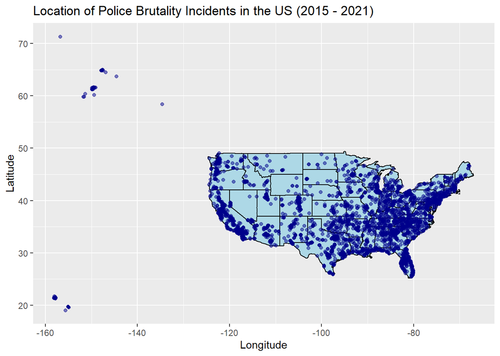

The blue dots in the map above represents the location (coordinates) where the encounter between the police and the victims occurred. The majority of incidents seem to be concentrated in the east coast.

### Number of Police Violence Encounters per Year (2015 - 2021)

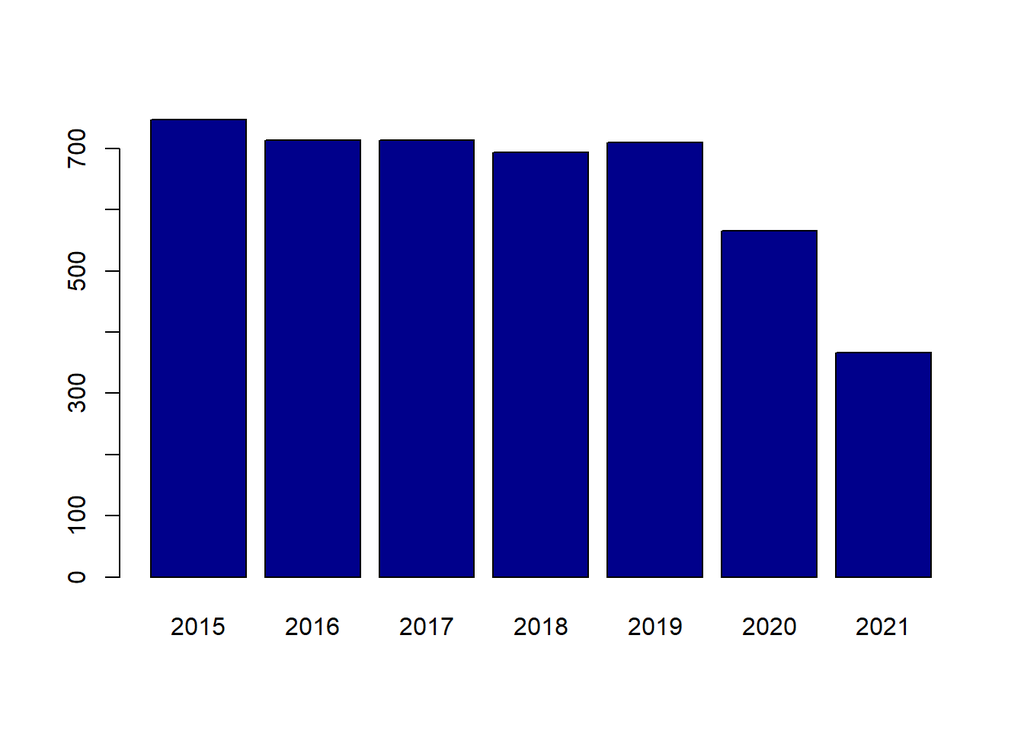

```r
#States with largest # of Incidents

table6 <- table(mpv_clean$year)

barplot(table6, col= "darkblue")
```

While the number of violent encounters with the police stayed about the same between 2015 and 2019, we can observed a decrease in 2020 and 2021. This decrase is most likely associated with social distancing and curfews imposed during the COVID-19 pandemic.

### States with Highest Number of Police Brutality Incidents (2015-2021)

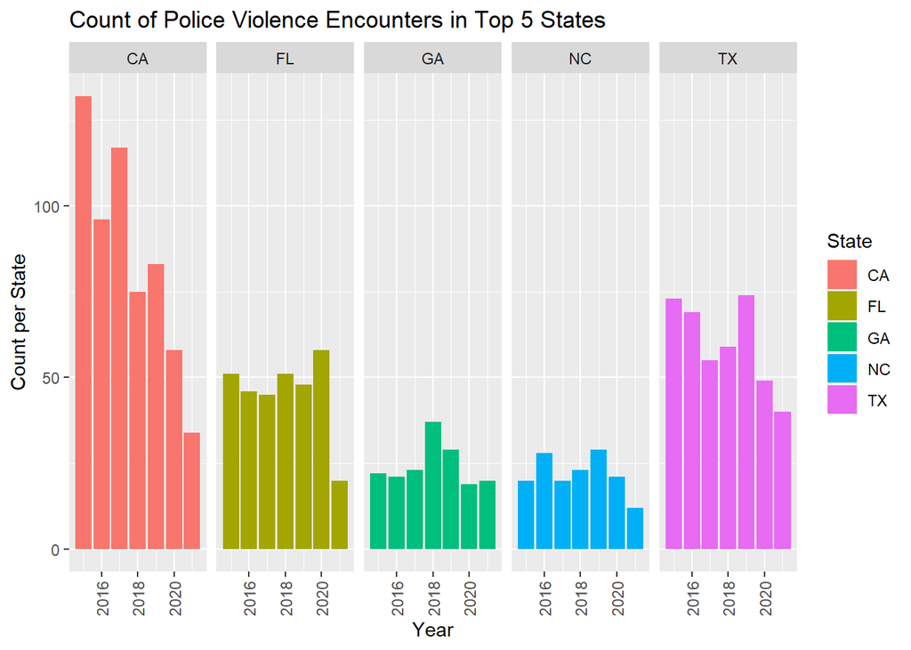

```r
#States with logest incidents

#finding states with most and lowest number of incidents

table6 <- ddply(mpv_clean, c('State'), summarize, count_inc= n())
df6 <- as.data.frame(table6)
df6_ordered <-  df6[order(df6$count_inc),]

top_states <- tail(df6_ordered, 5)
bottom_states <- head(df6_ordered, 5)

#finding states with the least incidents

top_states2 <- filter(mpv_clean, State == "NC" | State == "GA" | State == "FL" | State == "TX" | State == "CA")
bottom_states2 <- filter(mpv_clean, State == "RI" | State == "WY" | State == "MD" | State == "DE" | State == "SD")

table8 <- ddply(top_states2, c('State','year'), summarize, count= n())

graph1 <- ggplot(data = table8, aes(x = year, y = count, fill = State))
graph1 + facet_grid(~ State) + geom_bar(stat = "identity") + ylab("Count per State") + xlab("Year") + theme(axis.text.x = element_text(angle = 90, vjust = 0.5, hjust=1)) + ggtitle("Count of Police Violence Encounters in Top 5 States")
```

### States with Lowest Number of Police Brutality Incidents (2015-2021)

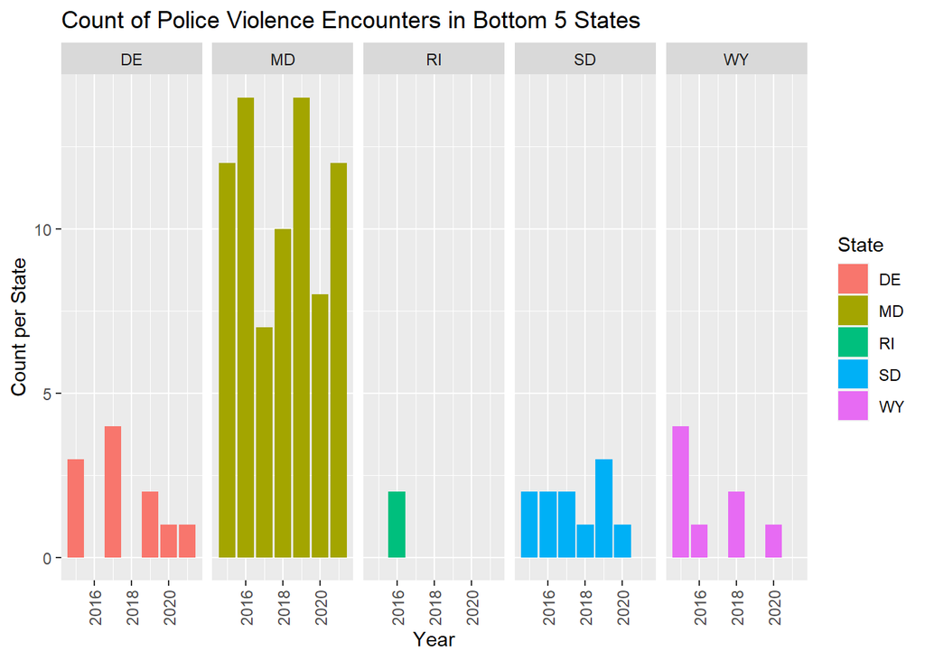

```r
table9 <- ddply(bottom_states2, c('State','year'), summarize, count= n())

graph2 <- ggplot(data = table9, aes(x = year, y = count, fill = State))
graph2 + facet_grid(~ State) + geom_bar(stat = "identity") + ylab("Count per State") + xlab("Year") +
  theme(axis.text.x = element_text(angle = 90, vjust = 0.5, hjust=1)) + ggtitle("Count of Police Violence Encounters in Bottom 5 States")
```

### Victims Age vs Race

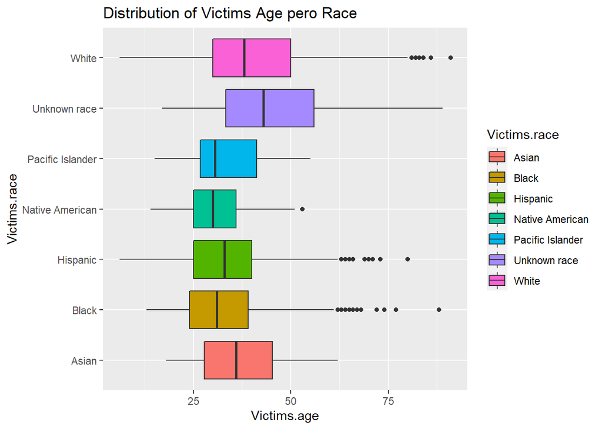

```r
ggplot(mpv_clean, aes(Victims.age, Victims.race, fill = Victims.race )) +         # Boxplot in ggplot2
  geom_boxplot() + ggtitle("Distribution of Victims Age pero Race")
```

Excluding the Victimcs with unknown race, the highest average age is found among those who were White and Asian. The largest spread of the data is found also among White as from all racial groups they had the largest number of victims. The lowest average age was found among those who were Black and Native American

### Cause of Death per Race

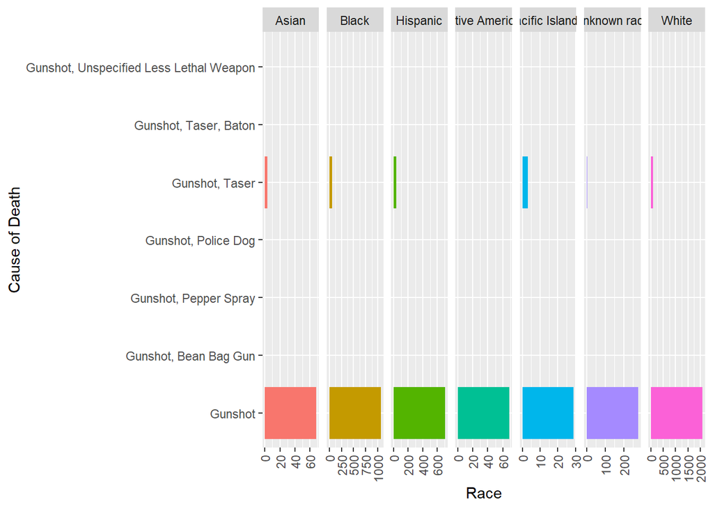

```r
table10 <- ddply(mpv_clean, c('Victims.race','Cause.of.death'), summarize, count= n())

levels(table10$Victims.race) <- c("A", "B", "H", "NA", "PI", "Unknown", "W")

graph1 <- ggplot(data = table10, aes(x = Cause.of.death, y = count, fill = Victims.race))
graph1 +  facet_grid(~ Victims.race, scales = "free_x") + geom_bar(stat = "identity") + coord_flip() + theme(legend.position='none') + ylab("Race") + xlab("Cause of Death") + theme(axis.text.x = element_text(angle = 90, vjust = 0.5, hjust=1))
```

When looking at cause of death per race, Gunshot seems to be the cause that is most common accross all races. Highest number of deaths can be observed among White and Black individuals.

### Correlation Metric on Selected Variables

The correlation matrix will allor us to identify whether we have variables that could be causing collinearity in our model.

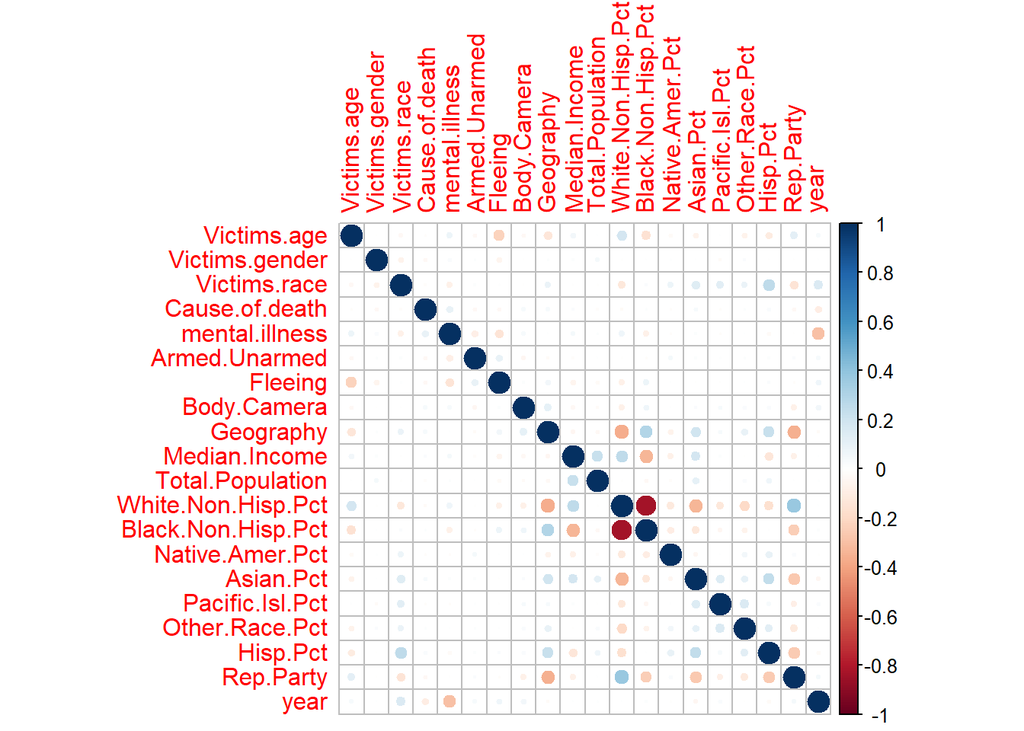

```r
mpv_df <- mpv_num[, c("Victims.age","Victims.gender", "Victims.race","Cause.of.death","mental.illness", "Armed.Unarmed",   "Fleeing", "Body.Camera", "Geography", "Median.Income", "Total.Population", "White.Non.Hisp.Pct", "Black.Non.Hisp.Pct", "Native.Amer.Pct", "Asian.Pct", "Pacific.Isl.Pct", "Other.Race.Pct", "Hisp.Pct", "Rep.Party", "year" )]

mpv_df2<- na.omit(mpv_df)


library(corrplot)
corrdata <- cor(mpv_df2)
corrplot(corrdata)
```

A new dataframe was created to include only the numerical variables that were already numerical in the dataset and the ones that were trasnformed from categorial into numerical above. This dataframe will be used to for the classification model below.

The correlation metrics indicate that from all the variables in our dataset only the percentage of the populations between white non-hispanic and black non hispanic were strongly correlated. The rest of the variables showed low levels of correlation.

# Clasification of Armed/Unarmed

In this section, a KNN model will be applied to predict whether the victims of police violence were armed or unarmed based on the features in the dataset. The purpose of doing this is to potentially prevent future killings.

I am hoping that with this model, we are to predict our target variable with an accuracy score above 80%

## Splitting the data

```r
library(caret)

mpv_df2$Armed.Unarmed <- as.factor(mpv_df2$Armed.Unarmed)


set.seed(1000)
#partition the data into a 70%/30% training/testing split
inTrain <- caret::createDataPartition(y = mpv_df2$Armed.Unarmed,
                               p = .70,
                               list = FALSE)

training <- mpv_df2[inTrain, ]
testing <- mpv_df2[-inTrain, ]


ctrl <- trainControl(method="repeatedcv", repeats=5)
```

## Fitting data in the model

```r
knnFit <- train(Armed.Unarmed ~ .,
                data=training,
                method="knn", metric="Accuracy",
                trControl=ctrl)
knnFit
```

```
## k-Nearest Neighbors
##
## 2867 samples
##   19 predictor
##    4 classes: '0', '1', '2', '3'
##
## No pre-processing
## Resampling: Cross-Validated (10 fold, repeated 5 times)
## Summary of sample sizes: 2581, 2581, 2580, 2581, 2580, 2581, ...
## Resampling results across tuning parameters:
##
##   k  Accuracy   Kappa
##   5  0.7478179  -0.0030791798
##   7  0.7644255  -0.0001309448
##   9  0.7718908  -0.0020462452
##
## Accuracy was used to select the optimal model using the largest value.
## The final value used for the model was k = 9.
```

## Testing set predictions

```r
knnClasses <- predict(knnFit, newdata = testing)
knnClasses
```

```
##    [1] 1 1 1 1 1 1 1 1 1 1 1 1 1 1 1 1 1 1 1 1 1 1 1 1 1 1 1 1 1 1 1 1 1 1 1 1 1
##   [38] 1 1 1 1 1 1 1 1 1 1 1 1 1 1 1 1 1 1 1 1 1 1 1 1 1 1 1 1 1 1 1 1 1 1 1 1 1
##   [75] 1 1 1 1 1 1 1 1 1 1 1 1 1 1 1 1 1 1 1 1 1 1 1 1 1 1 1 1 1 1 1 1 1 1 1 1 1
##  [112] 1 1 1 1 1 1 1 1 1 1 1 1 1 1 1 1 1 1 1 1 1 1 1 1 1 1 1 1 1 1 1 1 1 1 1 1 1
##  [149] 1 1 1 1 1 1 1 1 1 1 1 1 1 1 1 1 1 1 1 1 1 1 1 1 1 1 1 1 1 1 1 1 1 1 1 1 1
##  [186] 1 1 1 1 1 1 1 1 1 1 1 1 1 1 1 1 1 1 1 1 1 1 1 1 1 1 1 1 1 1 1 1 1 1 1 1 1
##  [223] 1 1 1 1 1 1 1 1 1 1 1 1 1 1 1 1 1 1 1 1 1 1 1 1 1 1 1 1 1 1 1 1 1 1 1 1 1
##  [260] 1 1 1 1 1 1 1 1 1 1 1 1 1 1 1 1 1 1 1 1 1 1 1 1 1 1 1 1 1 1 1 1 1 1 1 1 1
##  [297] 1 1 1 1 1 1 1 1 1 1 1 1 1 1 1 1 1 1 1 1 1 1 1 1 1 1 1 1 1 1 1 1 1 1 1 1 1
##  [334] 1 1 1 1 1 1 1 1 1 1 1 1 1 1 1 1 1 1 1 1 1 1 1 1 1 1 1 1 1 1 1 1 1 1 1 1 1
##  [371] 1 1 1 1 1 1 1 1 1 1 1 1 1 1 1 1 1 1 1 1 1 1 1 1 1 1 1 1 1 1 1 1 1 1 1 1 1
##  [408] 1 1 1 1 1 1 1 1 1 1 1 1 1 1 1 1 1 1 1 1 1 1 1 1 1 1 1 1 1 1 1 1 1 1 1 1 1
##  [445] 1 1 1 1 1 1 1 1 1 1 1 1 1 1 1 1 1 1 1 1 1 1 1 1 1 1 1 1 1 1 1 1 1 1 1 1 1
##  [482] 1 1 1 1 1 1 1 1 1 1 1 1 1 1 1 1 1 1 1 1 1 1 1 1 1 1 1 1 1 1 1 1 1 1 1 1 1
##  [519] 1 1 1 1 1 1 1 1 1 1 1 1 1 1 1 1 1 1 1 1 1 1 1 1 1 1 1 1 1 1 1 1 1 1 1 1 1
```

[output cut: 20 more lines]

## Performance Measures

```r
#performance measurement
postResample(knnClasses, testing$Armed.Unarmed)
```

```
##     Accuracy        Kappa
##  0.772801303 -0.005511631
```

# Confusion Matrix

```r
#confusion matrix
cmknn <-confusionMatrix(knnClasses, testing$Armed.Unarmed)
print(cmknn)
```

```
## Confusion Matrix and Statistics
##
##           Reference
## Prediction   0   1   2   3
##          0   0   3   0   0
##          1 117 949  82  75
##          2   0   1   0   0
##          3   0   1   0   0
##
## Overall Statistics
##
##                Accuracy : 0.7728
##                  95% CI : (0.7483, 0.796)
##     No Information Rate : 0.7769
##     P-Value [Acc > NIR] : 0.6489
##
##                   Kappa : -0.0055
##
##  Mcnemar's Test P-Value : NA
##
## Statistics by Class:
##
##                      Class: 0 Class: 1  Class: 2  Class: 3
## Sensitivity          0.000000   0.9948 0.0000000 0.0000000
## Specificity          0.997300   0.0000 0.9991274 0.9991327
## Pos Pred Value       0.000000   0.7760 0.0000000 0.0000000
## Neg Pred Value       0.904490   0.0000 0.9331703 0.9388753
## Prevalence           0.095277   0.7769 0.0667752 0.0610749
## Detection Rate       0.000000   0.7728 0.0000000 0.0000000
## Detection Prevalence 0.002443   0.9959 0.0008143 0.0008143
## Balanced Accuracy    0.498650   0.4974 0.4995637 0.4995663
```

By using KNN model fitted for the best number of neighbors (k=9), we were able to predict the individuals who were armed/unarmed with an accuracy score of 77%. While reviewing the results by class, this model predicted in most instances those who were alledgly armed. However, when it comes to those who were “unarmed”, “unclear” and “wehicle” all instances were predicted incorrectly as armed. Other techniques could be applied to improve this model, however, they are currently out of the scope of this analysis.

# CONCLUSIONS AND FINAL RECOMENDATIONS

While the KNN provided an accuracy score of 77%, this is insufficient to predict correctly those classes different from allegedly armed. A few recommendations to improve the model would be: - adding additional variables into the model that could help determine classes more precisely. - trying additional classification models such as Naive Bayes, Decision Trees and Logistic Regression - performing oversampling to make the quantity of data points equal for each category - transform the data using PCA

# LIMITATIONS OF THE PROJECT

- When removing Null values, the dataset was reduced to more than half. As such, this could have influenced the results obtained
- Not all of the variables were analyzed as part of EDA or included in the classification model due to the lack of consistency in the data, Future work should consider exploring the possibilities of adding this information into the model
- Median Income and percentages per race were not used as part of the EDA analysis as it was unclear at which level of income and % of the population this information was provided (state, level, county, Census track code, zip code, etc.)
- Police brutality killings should be looked at using % of population per race as looking at absolute values does not take population size into account.